# Homework 4

Spencer Baumruk

9/27/2020

## Page 106, Problem 4

```r
setwd("~/Box Sync/Classes/00_2020 Fall/ST 452/HW 4")
glakes <- read.delim("~/Box Sync/Classes/00_2020 Fall/ST 452/HW 4/glakes.txt")
head(glakes)
```

```
##   Case Tonnage Time
## 1    1    2213   17
## 2    2    3256   30
## 3    3   12203   68
## 4    4    7021   64
## 5    5     529   11
## 6    6    3192   55
```

First Model: $Time = \beta_0 + \beta_1 Tonnage + e$

Second Model: $log(Time) = \beta_0 + \beta_1 Tonnage^0.25 + e$

### (a) Does the straight line regression model (3.8) seem to fit the data well? If not, list any weaknesses apparent in model (3.8).

Let’s look at our data and our first model.

```r
m1 <- lm(data = glakes, Time ~ Tonnage)
summary(m1)
```

```
##
## Call:
## lm(formula = Time ~ Tonnage, data = glakes)
##
## Residuals:
##     Min      1Q  Median      3Q     Max
## -23.882  -6.397  -1.261   5.931  21.850
##
## Coefficients:
##              Estimate Std. Error t value Pr(>|t|)
## (Intercept) 12.344707   2.642633   4.671 6.32e-05 ***
## Tonnage      0.006518   0.000531  12.275 5.22e-13 ***
## ---
## Signif. codes:  0 '***' 0.001 '**' 0.01 '*' 0.05 '.' 0.1 ' ' 1
##
## Residual standard error: 10.7 on 29 degrees of freedom
## Multiple R-squared:  0.8386, Adjusted R-squared:  0.833
## F-statistic: 150.7 on 1 and 29 DF,  p-value: 5.218e-13
```

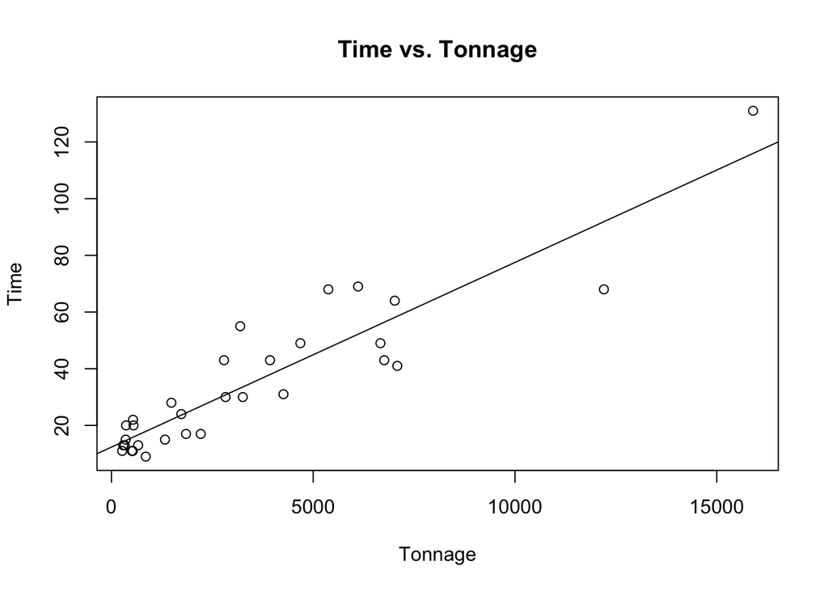

```r
plot(glakes$Time ~ glakes$Tonnage, xlab="Tonnage", ylab="Time", main="Time vs. Tonnage")
abline(m1)
```

We can see a fairly linear positive correlation between Tonnage and Time, with one data point that seems to have a high Time value. Let’s look to determine influential points and outliers.

```r
influence.measures(m1)
```

```
## Influence measures of
##   lm(formula = Time ~ Tonnage, data = glakes) :
##
##      dfb.1_ dfb.Tnng    dffit cov.r   cook.d    hat inf
## 1  -0.16212  0.05643 -0.17881 1.047 1.61e-02 0.0358
## 2  -0.04615  0.00270 -0.06098 1.100 1.92e-03 0.0323
## 3   0.53942 -1.39377 -1.50735 0.837 9.17e-01 0.2224   *
## 4   0.00453  0.10407  0.14746 1.121 1.11e-02 0.0643
## 5  -0.10680  0.06684 -0.10717 1.116 5.90e-03 0.0528
## 6   0.31074 -0.02504  0.40448 0.804 7.21e-02 0.0324
## 7   0.09078 -0.05662  0.09112 1.120 4.28e-03 0.0525
## 8   0.05148  0.03696  0.11196 1.087 6.42e-03 0.0362
## 9   0.06606  0.22803  0.38172 0.936 6.87e-02 0.0502
## 10  0.13562  0.20641  0.43365 0.840 8.44e-02 0.0417
## 11 -0.01327 -0.10764 -0.16111 1.106 1.32e-02 0.0583
```

[output cut: 20 more lines]

From our output, we can see that we have two leverage points (3 & 31). Let’s look at Cook’s distance to determine whether these points are bad leverage points.

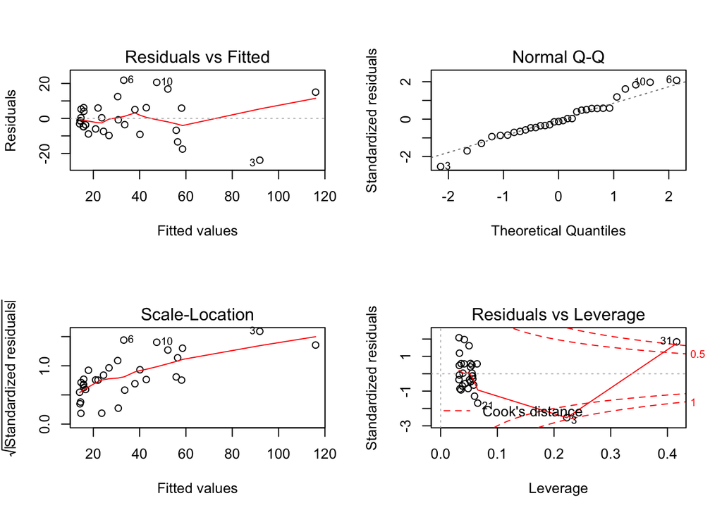

```r
par(mfrow=c(2,2))
plot(m1)
```

```r
influence.measures(m1)$is.inf[,"cook.d"]
```

```
##     1     2     3     4     5     6     7     8     9    10    11    12
## FALSE FALSE  TRUE FALSE FALSE FALSE FALSE FALSE FALSE FALSE FALSE FALSE
##    13    14    15    16    17    18    19    20    21    22    23    24
## FALSE FALSE FALSE FALSE FALSE FALSE FALSE FALSE FALSE FALSE FALSE FALSE
##    25    26    27    28    29    30    31
## FALSE FALSE FALSE FALSE FALSE FALSE  TRUE
```

We can see that both point 3 and point 31 were flagged for a high Cook’s distance, so we should either re-evaluate our model or remove them as outliers. We can also see a not-so-linear Normal QQ plot especially as it approaches higher quantiles. Our residual plot is somewhat even, but bumpy overall, with some scatter in the middle which is of slight concern and may indicate the presence of non-linear relationships. For the assumption of homoscedasticity, we can see from the Scale-Location plot that the values are not equally spread and the regression line is not very flat, which indicates unequal variance.

### (b) Suppose that model (3.8) was used to calculate a prediction interval for Time when Tonnage = 10,000. Would the interval be too short, too long or about right (i.e., valid)? Give a reason to support your answer.

Points 3 and 31 are just about equally and oppositely influential in skewing the model from its regression line. We can see from our model which includes these points that we would predict a value of 77.5234, but with these points removed, we would predict a value of 79.16965. This would suggest that if model (3.8) was used to calculated a prediction interval, the interval would be a bit too low, compared to a better model in which we remove outliers (or confirm the data are accurate).

```r
glakes_remo <- glakes[-c(3,31),]
m1_remo <- lm(data = glakes_remo, Time ~ Tonnage)
new.point <- data.frame(Tonnage=10000)
#Without Removing Outliers (using model 3.8)
predict(m1, newdata=new.point, interval = "prediction")
```

```
##       fit      lwr      upr
## 1 77.5234 54.17047 100.8763
```

```r
#Removing Outliers
predict(m1_remo, newdata=new.point, interval = "prediction")
```

```
##        fit      lwr      upr
## 1 79.16965 55.94824 102.3911
```

### (a) Is model (3.9) an improvement over model (3.8) in terms of predicting Time? If so, please describe all the ways in which it is an improvement.

Let’s take a look at our second model.

$log(Time) = \beta_0 + \beta_1 Tonnage^0.25 + e$

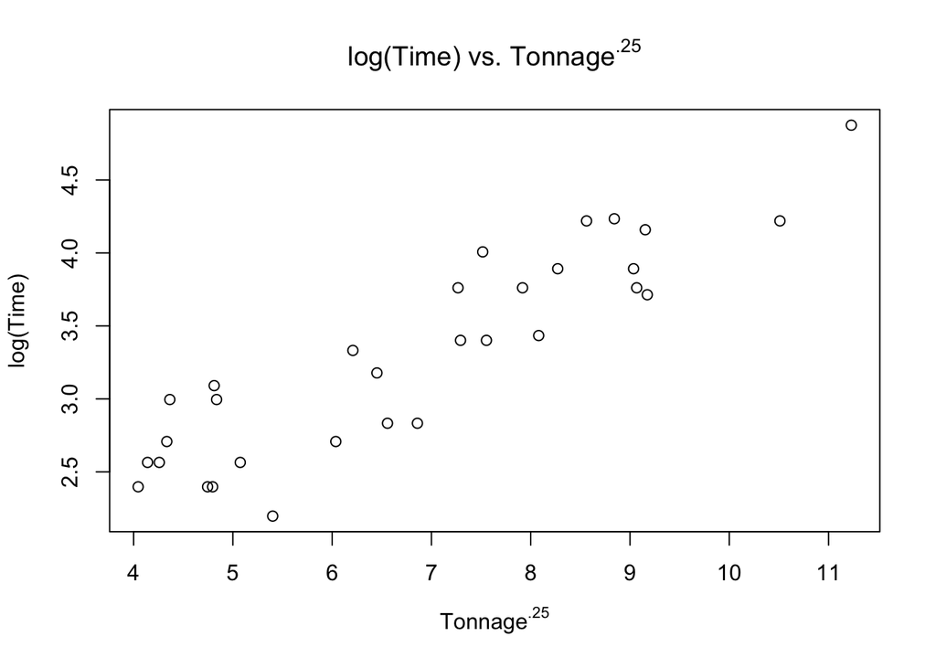

```r
newgl <- glakes %>% mutate(tonnage2 = Tonnage^.25, ltime = log(Time))
m2 <- lm(data = newgl, ltime ~ tonnage2)
par(mfrow=c(1,1))
plot(newgl$ltime ~ newgl$tonnage2, xlab=expression(paste("Tonnage"^".25")), ylab="log(Time)", main=expression(paste("log(Time) vs. Tonnage"^".25")))
```

```r
summary(m2)
```

```
##
## Call:
## lm(formula = ltime ~ tonnage2, data = newgl)
##
## Residuals:
##     Min      1Q  Median      3Q     Max
## -0.6607 -0.2410 -0.0044  0.2203  0.4956
##
## Coefficients:
##             Estimate Std. Error t value Pr(>|t|)
## (Intercept)  1.18842    0.19468   6.105  1.2e-06 ***
## tonnage2     0.30910    0.02728  11.332  3.6e-12 ***
## ---
## Signif. codes:  0 '***' 0.001 '**' 0.01 '*' 0.05 '.' 0.1 ' ' 1
##
## Residual standard error: 0.3034 on 29 degrees of freedom
## Multiple R-squared:  0.8158, Adjusted R-squared:  0.8094
## F-statistic: 128.4 on 1 and 29 DF,  p-value: 3.599e-12
```

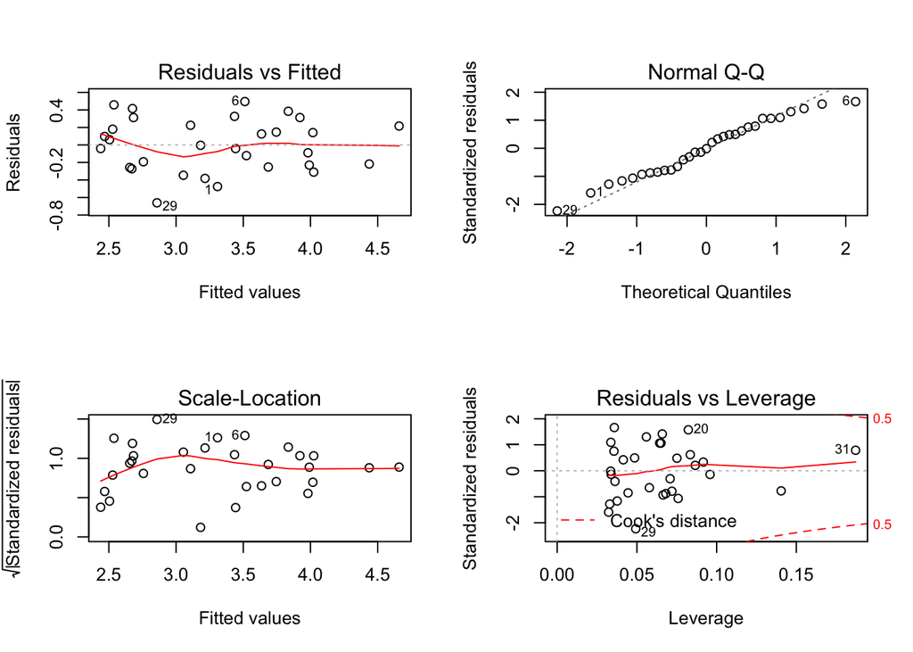

```r
par(mfrow=c(2,2))
plot(m2)
```

Looking at this model, we can see a few things. First, it meets more of our assumptions for least-squares regression, with a very well scattered and flat residual plot, and a good Normal QQ fit. We also have one leverage point, but based on Cook’s distance, it is a good leverage point. It also appears to meet our assumptions of homoscedascity. In these ways, the model (3.9) is an improvement over model (3.8).

### (b) List any weaknesses apparent in model (3.9).

Compared to model (3.8), model (3.9) has a lower multiple R-squared (0.8158 compared to 0.8386).